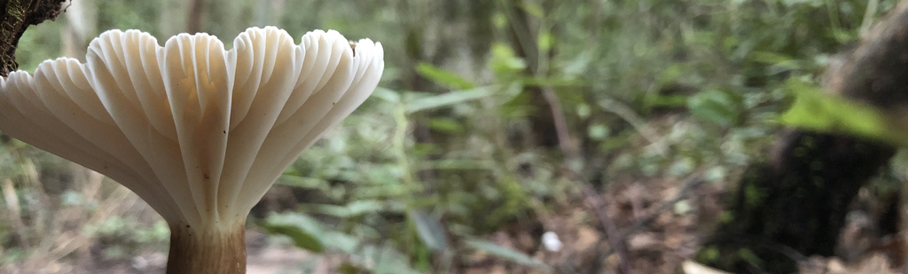

# Dr. Sören Weber

*botany/mycology/mycorrhizae*

[Oak Ridge National Laboratory](https://www.ornl.gov/staff-profile/soren-e-weber)  
weberse@ornl.gov  
[@sporen_weber](https://twitter.com/sporen_weber/)

I am a plant and fungal ecologist, deeply interested in how biological interactions within and between these groups of organisms influence the composition of communities and drive nutrient cycling in ecosystems. Since my bachelors, I have at different times fixated on various aspects of interactions between plants and fungi. A major throughline has been plant roots and the mycorrhizal fungi who inhabit them. In their search for nutrients, plant roots serve as a major conduit of carbon from the atmosphere to the soil (which is the largest store of carbon on land). Assisting in this search, most land-plants host mycorrhizal fungi - which use their threadlike hyphal network to acquire nutrients and exchange them with the plant for sugars and fatty acids. I think that plant roots, mycorrhizal fungi and the multitude of other organisms in the soil matrix are not only an understudied component of ecosystems, but may be the most important aspects of ecosystems.

Currently, I am researching how root growth distributions in peatlands are responding to climate change (elevated CO<sub>2</sub> and warming) at Oak Ridge National Laboratory. Peatlands are responsible for an immense amount of carbon stored in terrestrial ecosystems, and plant roots are the main source of carbon easily decayed by decomposers. The plants in these ecosystems range from the non-rooted *Sphagnum* sp., to shrubs with fine-roots, coniferous trees with shallow root systems and sedges with thick roots reaching deep within the peat layer. To address how root distribution among these plant functional types is responding to climate change, I am working on a large dataset of root images gathered from minirhizotrons at [SPRUCE](https://mnspruce.ornl.gov/) in northern Minnesota.

Previously, I investigated the trade of carbon and phosphorus between plants and their arbuscular mycorrhizal partners, during my PhD at the University of Zürich. I grew plants and arbuscular mycorrhizal fungi in configurable microcosms, and labelled the plant carbon pool with <sup>14</sup>C and the fungal phosphorus pools with <sup>32</sup> or <sup>33</sup>P. This allowed me to create several scenarios to investigate how resource exchange shifted when plants had choice between fungal partners, or fungi had choice between plant partners, as well as examine a more complex community without clear separation between plant and fungal choice. During my PhD I developed a lot of skills in designing experiments, constructing equipment and streamlining workflows in addition to an everdeepening appreciation for plant roots and mycorrhizal fungi.